# Risk Factor Analysis

## Outcome Variable

**Outcome Variable:** stunted

## Predictor Variables

**Intervention Variable:** anywast06

**Adjustment Set:**

- arm
- sex
- W_mage
- meducyrs
- month
- brthmon
- delta_W_mage
- delta_meducyrs
- delta_month
- delta_brthmon

## Stratifying Variables

The analysis was stratified on these variable(s):

- agecat
- studyid
- country

## Data Summary

| agecat | studyid | country | anywast06 | stunted | n_cell | n |
| --- | --- | --- | --- | --- | --- | --- |
| Birth | ki0047075b-MAL-ED | BANGLADESH | 0 | 0 | 163 | 255 |
| Birth | ki0047075b-MAL-ED | BANGLADESH | 0 | 1 | 35 | 255 |
| Birth | ki0047075b-MAL-ED | BANGLADESH | 1 | 0 | 47 | 255 |
| Birth | ki0047075b-MAL-ED | BANGLADESH | 1 | 1 | 10 | 255 |
| Birth | ki0047075b-MAL-ED | BRAZIL | 0 | 0 | 157 | 191 |
| Birth | ki0047075b-MAL-ED | BRAZIL | 0 | 1 | 21 | 191 |
| Birth | ki0047075b-MAL-ED | BRAZIL | 1 | 0 | 13 | 191 |
| Birth | ki0047075b-MAL-ED | BRAZIL | 1 | 1 | 0 | 191 |
| Birth | ki0047075b-MAL-ED | INDIA | 0 | 0 | 120 | 206 |
| Birth | ki0047075b-MAL-ED | INDIA | 0 | 1 | 24 | 206 |
| Birth | ki0047075b-MAL-ED | INDIA | 1 | 0 | 53 | 206 |
| Birth | ki0047075b-MAL-ED | INDIA | 1 | 1 | 9 | 206 |
| Birth | ki0047075b-MAL-ED | NEPAL | 0 | 0 | 128 | 173 |
| Birth | ki0047075b-MAL-ED | NEPAL | 0 | 1 | 13 | 173 |
| Birth | ki0047075b-MAL-ED | NEPAL | 1 | 0 | 27 | 173 |
| Birth | ki0047075b-MAL-ED | NEPAL | 1 | 1 | 5 | 173 |
| Birth | ki0047075b-MAL-ED | PERU | 0 | 0 | 245 | 286 |
| Birth | ki0047075b-MAL-ED | PERU | 0 | 1 | 30 | 286 |
| Birth | ki0047075b-MAL-ED | PERU | 1 | 0 | 8 | 286 |
| Birth | ki0047075b-MAL-ED | PERU | 1 | 1 | 3 | 286 |
| Birth | ki0047075b-MAL-ED | SOUTH AFRICA | 0 | 0 | 209 | 261 |
| Birth | ki0047075b-MAL-ED | SOUTH AFRICA | 0 | 1 | 21 | 261 |
| Birth | ki0047075b-MAL-ED | SOUTH AFRICA | 1 | 0 | 25 | 261 |
| Birth | ki0047075b-MAL-ED | SOUTH AFRICA | 1 | 1 | 6 | 261 |
| Birth | ki0047075b-MAL-ED | TANZANIA, UNITED REPUBLIC OF | 0 | 0 | 100 | 123 |
| Birth | ki0047075b-MAL-ED | TANZANIA, UNITED REPUBLIC OF | 0 | 1 | 17 | 123 |
| Birth | ki0047075b-MAL-ED | TANZANIA, UNITED REPUBLIC OF | 1 | 0 | 5 | 123 |
| Birth | ki0047075b-MAL-ED | TANZANIA, UNITED REPUBLIC OF | 1 | 1 | 1 | 123 |
| Birth | ki1000108-CMC-V-BCS-2002 | INDIA | 0 | 0 | 29 | 90 |
| Birth | ki1000108-CMC-V-BCS-2002 | INDIA | 0 | 1 | 7 | 90 |

[output cut: 170 more lines]

The following strata were considered:

- agecat: 24 months, studyid: ki0047075b-MAL-ED, country: BANGLADESH
- agecat: 24 months, studyid: ki0047075b-MAL-ED, country: BRAZIL
- agecat: 24 months, studyid: ki0047075b-MAL-ED, country: INDIA
- agecat: 24 months, studyid: ki0047075b-MAL-ED, country: NEPAL
- agecat: 24 months, studyid: ki0047075b-MAL-ED, country: PERU
- agecat: 24 months, studyid: ki0047075b-MAL-ED, country: SOUTH AFRICA
- agecat: 24 months, studyid: ki0047075b-MAL-ED, country: TANZANIA, UNITED REPUBLIC OF
- agecat: 24 months, studyid: ki1000108-CMC-V-BCS-2002, country: INDIA
- agecat: 24 months, studyid: ki1000108-IRC, country: INDIA
- agecat: 24 months, studyid: ki1017093b-PROVIDE, country: BANGLADESH
- agecat: 24 months, studyid: ki1066203-TanzaniaChild2, country: TANZANIA, UNITED REPUBLIC OF
- agecat: 24 months, studyid: ki1101329-Keneba, country: GAMBIA
- agecat: 24 months, studyid: ki1113344-GMS-Nepal, country: NEPAL
- agecat: 24 months, studyid: ki1114097-CMIN, country: BANGLADESH
- agecat: 24 months, studyid: ki1114097-CMIN, country: PERU
- agecat: 24 months, studyid: ki1114097-CONTENT, country: PERU
- agecat: 6 months, studyid: ki0047075b-MAL-ED, country: BANGLADESH
- agecat: 6 months, studyid: ki0047075b-MAL-ED, country: BRAZIL
- agecat: 6 months, studyid: ki0047075b-MAL-ED, country: INDIA
- agecat: 6 months, studyid: ki0047075b-MAL-ED, country: NEPAL
- agecat: 6 months, studyid: ki0047075b-MAL-ED, country: PERU
- agecat: 6 months, studyid: ki0047075b-MAL-ED, country: SOUTH AFRICA
- agecat: 6 months, studyid: ki0047075b-MAL-ED, country: TANZANIA, UNITED REPUBLIC OF
- agecat: 6 months, studyid: ki1000108-CMC-V-BCS-2002, country: INDIA
- agecat: 6 months, studyid: ki1000108-IRC, country: INDIA
- agecat: 6 months, studyid: ki1000109-EE, country: PAKISTAN
- agecat: 6 months, studyid: ki1000109-ResPak, country: PAKISTAN
- agecat: 6 months, studyid: ki1017093b-PROVIDE, country: BANGLADESH
- agecat: 6 months, studyid: ki1066203-TanzaniaChild2, country: TANZANIA, UNITED REPUBLIC OF
- agecat: 6 months, studyid: ki1101329-Keneba, country: GAMBIA
- agecat: 6 months, studyid: ki1112895-Guatemala BSC, country: GUATEMALA
- agecat: 6 months, studyid: ki1113344-GMS-Nepal, country: NEPAL
- agecat: 6 months, studyid: ki1114097-CMIN, country: BANGLADESH
- agecat: 6 months, studyid: ki1114097-CMIN, country: PERU
- agecat: 6 months, studyid: ki1114097-CONTENT, country: PERU
- agecat: Birth, studyid: ki0047075b-MAL-ED, country: BANGLADESH
- agecat: Birth, studyid: ki0047075b-MAL-ED, country: BRAZIL
- agecat: Birth, studyid: ki0047075b-MAL-ED, country: INDIA
- agecat: Birth, studyid: ki0047075b-MAL-ED, country: NEPAL
- agecat: Birth, studyid: ki0047075b-MAL-ED, country: PERU
- agecat: Birth, studyid: ki0047075b-MAL-ED, country: SOUTH AFRICA
- agecat: Birth, studyid: ki0047075b-MAL-ED, country: TANZANIA, UNITED REPUBLIC OF
- agecat: Birth, studyid: ki1000108-CMC-V-BCS-2002, country: INDIA
- agecat: Birth, studyid: ki1000108-IRC, country: INDIA
- agecat: Birth, studyid: ki1000109-EE, country: PAKISTAN
- agecat: Birth, studyid: ki1000109-ResPak, country: PAKISTAN
- agecat: Birth, studyid: ki1101329-Keneba, country: GAMBIA
- agecat: Birth, studyid: ki1114097-CMIN, country: BANGLADESH
- agecat: Birth, studyid: ki1114097-CMIN, country: PERU
- agecat: Birth, studyid: ki1114097-CONTENT, country: PERU

### Dropped Strata

Some strata were dropped due to rare outcomes:

- agecat: Birth, studyid: ki0047075b-MAL-ED, country: BRAZIL
- agecat: Birth, studyid: ki0047075b-MAL-ED, country: PERU
- agecat: Birth, studyid: ki0047075b-MAL-ED, country: TANZANIA, UNITED REPUBLIC OF
- agecat: Birth, studyid: ki1000109-EE, country: PAKISTAN
- agecat: Birth, studyid: ki1000109-ResPak, country: PAKISTAN
- agecat: Birth, studyid: ki1114097-CMIN, country: BANGLADESH
- agecat: Birth, studyid: ki1114097-CMIN, country: PERU
- agecat: Birth, studyid: ki1114097-CONTENT, country: PERU
- agecat: 6 months, studyid: ki0047075b-MAL-ED, country: BRAZIL
- agecat: 6 months, studyid: ki0047075b-MAL-ED, country: PERU
- agecat: 6 months, studyid: ki0047075b-MAL-ED, country: SOUTH AFRICA
- agecat: 6 months, studyid: ki0047075b-MAL-ED, country: TANZANIA, UNITED REPUBLIC OF
- agecat: 6 months, studyid: ki1112895-Guatemala BSC, country: GUATEMALA
- agecat: 6 months, studyid: ki1114097-CONTENT, country: PERU
- agecat: 24 months, studyid: ki0047075b-MAL-ED, country: BRAZIL
- agecat: 24 months, studyid: ki0047075b-MAL-ED, country: PERU
- agecat: 24 months, studyid: ki0047075b-MAL-ED, country: TANZANIA, UNITED REPUBLIC OF
- agecat: 24 months, studyid: ki1066203-TanzaniaChild2, country: TANZANIA, UNITED REPUBLIC OF
- agecat: 24 months, studyid: ki1114097-CONTENT, country: PERU

## Methods Detail

We’re interested in the causal parameters $E[Y_a]$ for all values of $a \in \mathcal{A}$. These parameters represent the mean outcome if, possibly contrary to fact, we intervened to set all units to have $A=a$. Under the randomization and positivity assumptions, these are identified by the statistical parameters $\psi_a=E_W[E_{Y|A,W}(Y|A=a,W)]$. In addition, we’re interested in the mean of $Y$, $E[Y]$ under no intervention (the observed mean). We will estimate these parameters by using SuperLearner to fit the relevant likelihood factors – $E_{Y|A,W}(Y|A=a,W)$ and $p(A=a|W)$, and then updating our likelihood fit using a joint TMLE.

For unadjusted analyses ($W=\{\}$), initial likelihoods were estimated using Lrnr_glm to estimate the simple $E(Y|A)$ and Lrnr_mean to estimate $p(A)$. For adjusted analyses, a small library containing Lrnr_glmnet, Lrnr_xgboost, and Lrnr_mean was used.

Having estimated these parameters, we will then use the delta method to estimate relative risks and attributable risks relative to a prespecified baseline level of $A$.

# Results Detail

## Results Plots

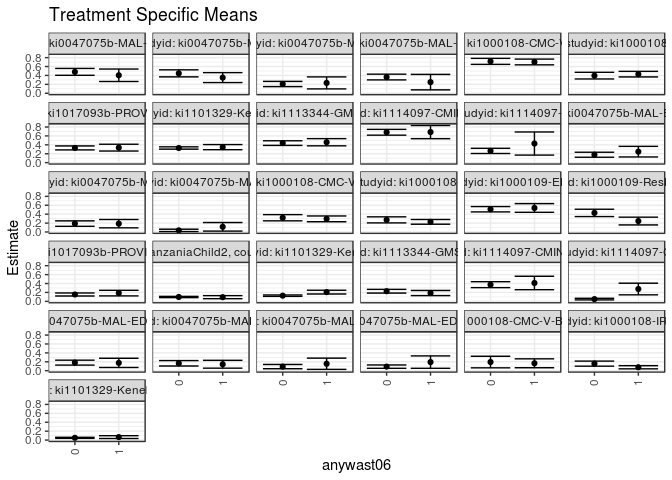

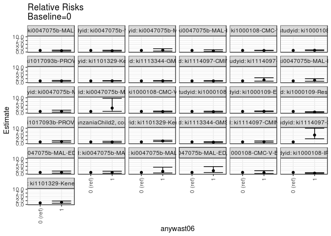

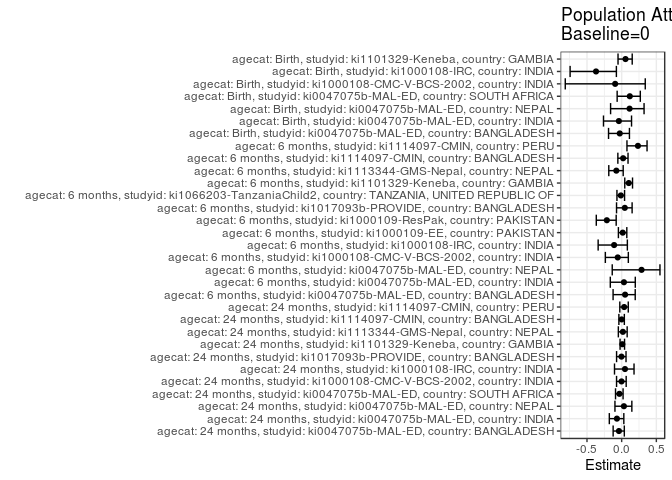

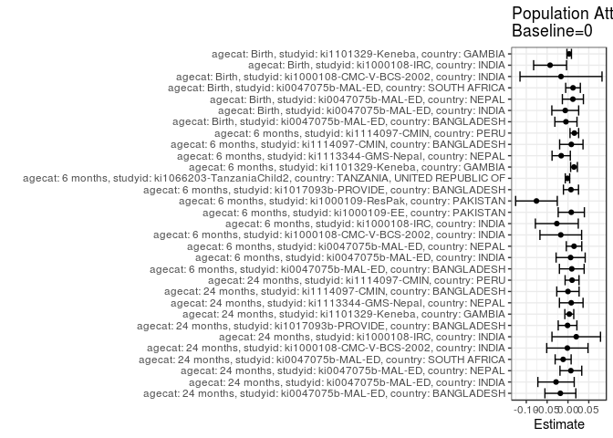

## Results Table

### Parameter: TSM

| agecat | studyid | country | intervention_level | baseline_level | estimate | ci_lower | ci_upper |
| --- | --- | --- | --- | --- | --- | --- | --- |
| Birth | ki0047075b-MAL-ED | BANGLADESH | 0 | NA | 0.1813498 | 0.1261032 | 0.2365963 |
| Birth | ki0047075b-MAL-ED | BANGLADESH | 1 | NA | 0.1755876 | 0.0718558 | 0.2793193 |
| Birth | ki0047075b-MAL-ED | INDIA | 0 | NA | 0.1666667 | 0.1056488 | 0.2276846 |
| Birth | ki0047075b-MAL-ED | INDIA | 1 | NA | 0.1451613 | 0.0572638 | 0.2330588 |
| Birth | ki0047075b-MAL-ED | NEPAL | 0 | NA | 0.0921986 | 0.0443075 | 0.1400897 |
| Birth | ki0047075b-MAL-ED | NEPAL | 1 | NA | 0.1562500 | 0.0300821 | 0.2824179 |
| Birth | ki0047075b-MAL-ED | SOUTH AFRICA | 0 | NA | 0.0913043 | 0.0540075 | 0.1286012 |
| Birth | ki0047075b-MAL-ED | SOUTH AFRICA | 1 | NA | 0.1935484 | 0.0542055 | 0.3328913 |
| Birth | ki1000108-CMC-V-BCS-2002 | INDIA | 0 | NA | 0.1944444 | 0.0644369 | 0.3244520 |
| Birth | ki1000108-CMC-V-BCS-2002 | INDIA | 1 | NA | 0.1666667 | 0.0667101 | 0.2666232 |
| Birth | ki1000108-IRC | INDIA | 0 | NA | 0.1588591 | 0.1022348 | 0.2154833 |
| Birth | ki1000108-IRC | INDIA | 1 | NA | 0.0776105 | 0.0418898 | 0.1133311 |
| Birth | ki1101329-Keneba | GAMBIA | 0 | NA | 0.0502697 | 0.0383028 | 0.0622365 |
| Birth | ki1101329-Keneba | GAMBIA | 1 | NA | 0.0668550 | 0.0355800 | 0.0981300 |
| 6 months | ki0047075b-MAL-ED | BANGLADESH | 0 | NA | 0.1775404 | 0.1212640 | 0.2338167 |
| 6 months | ki0047075b-MAL-ED | BANGLADESH | 1 | NA | 0.2462685 | 0.1274288 | 0.3651082 |
| 6 months | ki0047075b-MAL-ED | INDIA | 0 | NA | 0.1885013 | 0.1274153 | 0.2495874 |
| 6 months | ki0047075b-MAL-ED | INDIA | 1 | NA | 0.1870204 | 0.0933229 | 0.2807180 |
| 6 months | ki0047075b-MAL-ED | NEPAL | 0 | NA | 0.0362694 | 0.0098368 | 0.0627020 |
| 6 months | ki0047075b-MAL-ED | NEPAL | 1 | NA | 0.1162791 | 0.0202629 | 0.2122952 |
| 6 months | ki1000108-CMC-V-BCS-2002 | INDIA | 0 | NA | 0.3204888 | 0.2509086 | 0.3900691 |
| 6 months | ki1000108-CMC-V-BCS-2002 | INDIA | 1 | NA | 0.2949211 | 0.2305105 | 0.3593318 |
| 6 months | ki1000108-IRC | INDIA | 0 | NA | 0.2724241 | 0.2042162 | 0.3406320 |
| 6 months | ki1000108-IRC | INDIA | 1 | NA | 0.2278504 | 0.1748694 | 0.2808314 |
| 6 months | ki1000109-EE | PAKISTAN | 0 | NA | 0.5108316 | 0.4509606 | 0.5707026 |
| 6 months | ki1000109-EE | PAKISTAN | 1 | NA | 0.5397534 | 0.4419049 | 0.6376019 |
| 6 months | ki1000109-ResPak | PAKISTAN | 0 | NA | 0.4287922 | 0.3463900 | 0.5111944 |
| 6 months | ki1000109-ResPak | PAKISTAN | 1 | NA | 0.2455308 | 0.1583552 | 0.3327064 |
| 6 months | ki1017093b-PROVIDE | BANGLADESH | 0 | NA | 0.1539972 | 0.1200219 | 0.1879725 |
| 6 months | ki1017093b-PROVIDE | BANGLADESH | 1 | NA | 0.1854757 | 0.1225576 | 0.2483937 |
| 6 months | ki1066203-TanzaniaChild2 | TANZANIA, UNITED REPUBLIC OF | 0 | NA | 0.0982259 | 0.0842090 | 0.1122428 |
| 6 months | ki1066203-TanzaniaChild2 | TANZANIA, UNITED REPUBLIC OF | 1 | NA | 0.0937898 | 0.0594601 | 0.1281195 |
| 6 months | ki1101329-Keneba | GAMBIA | 0 | NA | 0.1274221 | 0.1116033 | 0.1432408 |
| 6 months | ki1101329-Keneba | GAMBIA | 1 | NA | 0.2075658 | 0.1651265 | 0.2500050 |
| 6 months | ki1113344-GMS-Nepal | NEPAL | 0 | NA | 0.2276112 | 0.1861407 | 0.2690818 |
| 6 months | ki1113344-GMS-Nepal | NEPAL | 1 | NA | 0.1868162 | 0.1293010 | 0.2443314 |
| 6 months | ki1114097-CMIN | BANGLADESH | 0 | NA | 0.3746201 | 0.3076550 | 0.4415852 |
| 6 months | ki1114097-CMIN | BANGLADESH | 1 | NA | 0.4121994 | 0.2611912 | 0.5632077 |
| 6 months | ki1114097-CMIN | PERU | 0 | NA | 0.0500424 | 0.0322970 | 0.0677878 |
| 6 months | ki1114097-CMIN | PERU | 1 | NA | 0.2768007 | 0.1459550 | 0.4076465 |
| 24 months | ki0047075b-MAL-ED | BANGLADESH | 0 | NA | 0.4804356 | 0.4031937 | 0.5576774 |
| 24 months | ki0047075b-MAL-ED | BANGLADESH | 1 | NA | 0.4043604 | 0.2642353 | 0.5444854 |
| 24 months | ki0047075b-MAL-ED | INDIA | 0 | NA | 0.4471006 | 0.3681641 | 0.5260371 |
| 24 months | ki0047075b-MAL-ED | INDIA | 1 | NA | 0.3520900 | 0.2404655 | 0.4637146 |
| 24 months | ki0047075b-MAL-ED | NEPAL | 0 | NA | 0.2079136 | 0.1494853 | 0.2663419 |
| 24 months | ki0047075b-MAL-ED | NEPAL | 1 | NA | 0.2324769 | 0.0978465 | 0.3671073 |
| 24 months | ki0047075b-MAL-ED | SOUTH AFRICA | 0 | NA | 0.3644860 | 0.2998672 | 0.4291047 |
| 24 months | ki0047075b-MAL-ED | SOUTH AFRICA | 1 | NA | 0.2500000 | 0.0763969 | 0.4236031 |
| 24 months | ki1000108-CMC-V-BCS-2002 | INDIA | 0 | NA | 0.7160852 | 0.6489677 | 0.7832028 |
| 24 months | ki1000108-CMC-V-BCS-2002 | INDIA | 1 | NA | 0.7027301 | 0.6386205 | 0.7668397 |
| 24 months | ki1000108-IRC | INDIA | 0 | NA | 0.3957667 | 0.3207152 | 0.4708182 |
| 24 months | ki1000108-IRC | INDIA | 1 | NA | 0.4289381 | 0.3665416 | 0.4913346 |
| 24 months | ki1017093b-PROVIDE | BANGLADESH | 0 | NA | 0.3302710 | 0.2858366 | 0.3747054 |
| 24 months | ki1017093b-PROVIDE | BANGLADESH | 1 | NA | 0.3363367 | 0.2601666 | 0.4125068 |
| 24 months | ki1101329-Keneba | GAMBIA | 0 | NA | 0.3286057 | 0.3030298 | 0.3541816 |
| 24 months | ki1101329-Keneba | GAMBIA | 1 | NA | 0.3477155 | 0.2903552 | 0.4050758 |
| 24 months | ki1113344-GMS-Nepal | NEPAL | 0 | NA | 0.4389900 | 0.3870187 | 0.4909612 |
| 24 months | ki1113344-GMS-Nepal | NEPAL | 1 | NA | 0.4579113 | 0.3768784 | 0.5389442 |
| 24 months | ki1114097-CMIN | BANGLADESH | 0 | NA | 0.6818580 | 0.6169951 | 0.7467210 |
| 24 months | ki1114097-CMIN | BANGLADESH | 1 | NA | 0.6857261 | 0.5377942 | 0.8336580 |
| 24 months | ki1114097-CMIN | PERU | 0 | NA | 0.2636364 | 0.2052898 | 0.3219830 |
| 24 months | ki1114097-CMIN | PERU | 1 | NA | 0.4285714 | 0.1687909 | 0.6883520 |

### Parameter: E(Y)

| agecat | studyid | country | intervention_level | baseline_level | estimate | ci_lower | ci_upper |
| --- | --- | --- | --- | --- | --- | --- | --- |
| Birth | ki0047075b-MAL-ED | BANGLADESH | NA | NA | 0.1764706 | 0.1295885 | 0.2233527 |
| Birth | ki0047075b-MAL-ED | INDIA | NA | NA | 0.1601942 | 0.1099849 | 0.2104035 |
| Birth | ki0047075b-MAL-ED | NEPAL | NA | NA | 0.1040462 | 0.0584174 | 0.1496751 |
| Birth | ki0047075b-MAL-ED | SOUTH AFRICA | NA | NA | 0.1034483 | 0.0664305 | 0.1404661 |
| Birth | ki1000108-CMC-V-BCS-2002 | INDIA | NA | NA | 0.1777778 | 0.0983474 | 0.2572081 |
| Birth | ki1000108-IRC | INDIA | NA | NA | 0.1159794 | 0.0840777 | 0.1478811 |
| Birth | ki1101329-Keneba | GAMBIA | NA | NA | 0.0532122 | 0.0420018 | 0.0644226 |
| 6 months | ki0047075b-MAL-ED | BANGLADESH | NA | NA | 0.1867220 | 0.1374205 | 0.2360234 |
| 6 months | ki0047075b-MAL-ED | INDIA | NA | NA | 0.1949153 | 0.1442678 | 0.2455627 |
| 6 months | ki0047075b-MAL-ED | NEPAL | NA | NA | 0.0508475 | 0.0227597 | 0.0789352 |
| 6 months | ki1000108-CMC-V-BCS-2002 | INDIA | NA | NA | 0.3032787 | 0.2561210 | 0.3504363 |
| 6 months | ki1000108-IRC | INDIA | NA | NA | 0.2457002 | 0.2038248 | 0.2875757 |
| 6 months | ki1000109-EE | PAKISTAN | NA | NA | 0.5188172 | 0.4679751 | 0.5696593 |
| 6 months | ki1000109-ResPak | PAKISTAN | NA | NA | 0.3531915 | 0.2919518 | 0.4144312 |
| 6 months | ki1017093b-PROVIDE | BANGLADESH | NA | NA | 0.1612350 | 0.1313580 | 0.1911120 |
| 6 months | ki1066203-TanzaniaChild2 | TANZANIA, UNITED REPUBLIC OF | NA | NA | 0.0970922 | 0.0842059 | 0.1099785 |
| 6 months | ki1101329-Keneba | GAMBIA | NA | NA | 0.1419543 | 0.1268686 | 0.1570400 |
| 6 months | ki1113344-GMS-Nepal | NEPAL | NA | NA | 0.2113677 | 0.1776128 | 0.2451225 |
| 6 months | ki1114097-CMIN | BANGLADESH | NA | NA | 0.3827160 | 0.3214780 | 0.4439541 |
| 6 months | ki1114097-CMIN | PERU | NA | NA | 0.0653907 | 0.0460250 | 0.0847565 |
| 24 months | ki0047075b-MAL-ED | BANGLADESH | NA | NA | 0.4622642 | 0.3949918 | 0.5295365 |
| 24 months | ki0047075b-MAL-ED | INDIA | NA | NA | 0.4185022 | 0.3541865 | 0.4828179 |
| 24 months | ki0047075b-MAL-ED | NEPAL | NA | NA | 0.2149123 | 0.1614774 | 0.2683472 |
| 24 months | ki0047075b-MAL-ED | SOUTH AFRICA | NA | NA | 0.3529412 | 0.2921001 | 0.4137823 |
| 24 months | ki1000108-CMC-V-BCS-2002 | INDIA | NA | NA | 0.7146739 | 0.6684741 | 0.7608737 |
| 24 months | ki1000108-IRC | INDIA | NA | NA | 0.4156479 | 0.3678270 | 0.4634689 |
| 24 months | ki1017093b-PROVIDE | BANGLADESH | NA | NA | 0.3292894 | 0.2909105 | 0.3676684 |
| 24 months | ki1101329-Keneba | GAMBIA | NA | NA | 0.3318414 | 0.3084975 | 0.3551853 |
| 24 months | ki1113344-GMS-Nepal | NEPAL | NA | NA | 0.4468938 | 0.4032281 | 0.4905594 |
| 24 months | ki1114097-CMIN | BANGLADESH | NA | NA | 0.6818182 | 0.6230135 | 0.7406228 |
| 24 months | ki1114097-CMIN | PERU | NA | NA | 0.2735043 | 0.2162683 | 0.3307402 |

### Parameter: RR

| agecat | studyid | country | intervention_level | baseline_level | estimate | ci_lower | ci_upper |
| --- | --- | --- | --- | --- | --- | --- | --- |
| Birth | ki0047075b-MAL-ED | BANGLADESH | 0 | 0 | 1.0000000 | 1.0000000 | 1.0000000 |
| Birth | ki0047075b-MAL-ED | BANGLADESH | 1 | 0 | 0.9682262 | 0.4965047 | 1.8881228 |
| Birth | ki0047075b-MAL-ED | INDIA | 0 | 0 | 1.0000000 | 1.0000000 | 1.0000000 |
| Birth | ki0047075b-MAL-ED | INDIA | 1 | 0 | 0.8709677 | 0.4292393 | 1.7672773 |
| Birth | ki0047075b-MAL-ED | NEPAL | 0 | 0 | 1.0000000 | 1.0000000 | 1.0000000 |
| Birth | ki0047075b-MAL-ED | NEPAL | 1 | 0 | 1.6947115 | 0.6488162 | 4.4265957 |
| Birth | ki0047075b-MAL-ED | SOUTH AFRICA | 0 | 0 | 1.0000000 | 1.0000000 | 1.0000000 |
| Birth | ki0047075b-MAL-ED | SOUTH AFRICA | 1 | 0 | 2.1198157 | 0.9264235 | 4.8505013 |
| Birth | ki1000108-CMC-V-BCS-2002 | INDIA | 0 | 0 | 1.0000000 | 1.0000000 | 1.0000000 |
| Birth | ki1000108-CMC-V-BCS-2002 | INDIA | 1 | 0 | 0.8571429 | 0.3491232 | 2.1043973 |
| Birth | ki1000108-IRC | INDIA | 0 | 0 | 1.0000000 | 1.0000000 | 1.0000000 |
| Birth | ki1000108-IRC | INDIA | 1 | 0 | 0.4885491 | 0.2722970 | 0.8765438 |
| Birth | ki1101329-Keneba | GAMBIA | 0 | 0 | 1.0000000 | 1.0000000 | 1.0000000 |
| Birth | ki1101329-Keneba | GAMBIA | 1 | 0 | 1.3299274 | 0.7866981 | 2.2482664 |
| 6 months | ki0047075b-MAL-ED | BANGLADESH | 0 | 0 | 1.0000000 | 1.0000000 | 1.0000000 |
| 6 months | ki0047075b-MAL-ED | BANGLADESH | 1 | 0 | 1.3871128 | 0.7785570 | 2.4713436 |
| 6 months | ki0047075b-MAL-ED | INDIA | 0 | 0 | 1.0000000 | 1.0000000 | 1.0000000 |
| 6 months | ki0047075b-MAL-ED | INDIA | 1 | 0 | 0.9921439 | 0.5455679 | 1.8042657 |
| 6 months | ki0047075b-MAL-ED | NEPAL | 0 | 0 | 1.0000000 | 1.0000000 | 1.0000000 |
| 6 months | ki0047075b-MAL-ED | NEPAL | 1 | 0 | 3.2059801 | 1.0657387 | 9.6443043 |
| 6 months | ki1000108-CMC-V-BCS-2002 | INDIA | 0 | 0 | 1.0000000 | 1.0000000 | 1.0000000 |
| 6 months | ki1000108-CMC-V-BCS-2002 | INDIA | 1 | 0 | 0.9202229 | 0.6762181 | 1.2522737 |
| 6 months | ki1000108-IRC | INDIA | 0 | 0 | 1.0000000 | 1.0000000 | 1.0000000 |
| 6 months | ki1000108-IRC | INDIA | 1 | 0 | 0.8363813 | 0.5942287 | 1.1772130 |
| 6 months | ki1000109-EE | PAKISTAN | 0 | 0 | 1.0000000 | 1.0000000 | 1.0000000 |
| 6 months | ki1000109-EE | PAKISTAN | 1 | 0 | 1.0566171 | 0.8512195 | 1.3115767 |
| 6 months | ki1000109-ResPak | PAKISTAN | 0 | 0 | 1.0000000 | 1.0000000 | 1.0000000 |
| 6 months | ki1000109-ResPak | PAKISTAN | 1 | 0 | 0.5726103 | 0.3822484 | 0.8577734 |
| 6 months | ki1017093b-PROVIDE | BANGLADESH | 0 | 0 | 1.0000000 | 1.0000000 | 1.0000000 |
| 6 months | ki1017093b-PROVIDE | BANGLADESH | 1 | 0 | 1.2044090 | 0.8029909 | 1.8064973 |
| 6 months | ki1066203-TanzaniaChild2 | TANZANIA, UNITED REPUBLIC OF | 0 | 0 | 1.0000000 | 1.0000000 | 1.0000000 |
| 6 months | ki1066203-TanzaniaChild2 | TANZANIA, UNITED REPUBLIC OF | 1 | 0 | 0.9548375 | 0.6446417 | 1.4142965 |
| 6 months | ki1101329-Keneba | GAMBIA | 0 | 0 | 1.0000000 | 1.0000000 | 1.0000000 |
| 6 months | ki1101329-Keneba | GAMBIA | 1 | 0 | 1.6289628 | 1.2826604 | 2.0687627 |
| 6 months | ki1113344-GMS-Nepal | NEPAL | 0 | 0 | 1.0000000 | 1.0000000 | 1.0000000 |
| 6 months | ki1113344-GMS-Nepal | NEPAL | 1 | 0 | 0.8207687 | 0.5736218 | 1.1743995 |
| 6 months | ki1114097-CMIN | BANGLADESH | 0 | 0 | 1.0000000 | 1.0000000 | 1.0000000 |
| 6 months | ki1114097-CMIN | BANGLADESH | 1 | 0 | 1.1003132 | 0.7327451 | 1.6522651 |
| 6 months | ki1114097-CMIN | PERU | 0 | 0 | 1.0000000 | 1.0000000 | 1.0000000 |
| 6 months | ki1114097-CMIN | PERU | 1 | 0 | 5.5313272 | 3.0635677 | 9.9869116 |
| 24 months | ki0047075b-MAL-ED | BANGLADESH | 0 | 0 | 1.0000000 | 1.0000000 | 1.0000000 |
| 24 months | ki0047075b-MAL-ED | BANGLADESH | 1 | 0 | 0.8416537 | 0.5738913 | 1.2343469 |
| 24 months | ki0047075b-MAL-ED | INDIA | 0 | 0 | 1.0000000 | 1.0000000 | 1.0000000 |
| 24 months | ki0047075b-MAL-ED | INDIA | 1 | 0 | 0.7874962 | 0.5483722 | 1.1308930 |
| 24 months | ki0047075b-MAL-ED | NEPAL | 0 | 0 | 1.0000000 | 1.0000000 | 1.0000000 |
| 24 months | ki0047075b-MAL-ED | NEPAL | 1 | 0 | 1.1181418 | 0.5870863 | 2.1295696 |
| 24 months | ki0047075b-MAL-ED | SOUTH AFRICA | 0 | 0 | 1.0000000 | 1.0000000 | 1.0000000 |
| 24 months | ki0047075b-MAL-ED | SOUTH AFRICA | 1 | 0 | 0.6858974 | 0.3349703 | 1.4044687 |
| 24 months | ki1000108-CMC-V-BCS-2002 | INDIA | 0 | 0 | 1.0000000 | 1.0000000 | 1.0000000 |
| 24 months | ki1000108-CMC-V-BCS-2002 | INDIA | 1 | 0 | 0.9813498 | 0.8607687 | 1.1188226 |
| 24 months | ki1000108-IRC | INDIA | 0 | 0 | 1.0000000 | 1.0000000 | 1.0000000 |
| 24 months | ki1000108-IRC | INDIA | 1 | 0 | 1.0838154 | 0.8531420 | 1.3768586 |
| 24 months | ki1017093b-PROVIDE | BANGLADESH | 0 | 0 | 1.0000000 | 1.0000000 | 1.0000000 |
| 24 months | ki1017093b-PROVIDE | BANGLADESH | 1 | 0 | 1.0183656 | 0.7822484 | 1.3257534 |
| 24 months | ki1101329-Keneba | GAMBIA | 0 | 0 | 1.0000000 | 1.0000000 | 1.0000000 |
| 24 months | ki1101329-Keneba | GAMBIA | 1 | 0 | 1.0581542 | 0.8817058 | 1.2699136 |
| 24 months | ki1113344-GMS-Nepal | NEPAL | 0 | 0 | 1.0000000 | 1.0000000 | 1.0000000 |
| 24 months | ki1113344-GMS-Nepal | NEPAL | 1 | 0 | 1.0431021 | 0.8433670 | 1.2901405 |
| 24 months | ki1114097-CMIN | BANGLADESH | 0 | 0 | 1.0000000 | 1.0000000 | 1.0000000 |
| 24 months | ki1114097-CMIN | BANGLADESH | 1 | 0 | 1.0056728 | 0.7945809 | 1.2728443 |
| 24 months | ki1114097-CMIN | PERU | 0 | 0 | 1.0000000 | 1.0000000 | 1.0000000 |
| 24 months | ki1114097-CMIN | PERU | 1 | 0 | 1.6256158 | 0.8526495 | 3.0993118 |

### Parameter: PAR

| agecat | studyid | country | intervention_level | baseline_level | estimate | ci_lower | ci_upper |
| --- | --- | --- | --- | --- | --- | --- | --- |
| Birth | ki0047075b-MAL-ED | BANGLADESH | 0 | NA | -0.0048792 | -0.0314181 | 0.0216597 |
| Birth | ki0047075b-MAL-ED | INDIA | 0 | NA | -0.0064725 | -0.0387049 | 0.0257599 |
| Birth | ki0047075b-MAL-ED | NEPAL | 0 | NA | 0.0118477 | -0.0133896 | 0.0370850 |
| Birth | ki0047075b-MAL-ED | SOUTH AFRICA | 0 | NA | 0.0121439 | -0.0054544 | 0.0297423 |
| Birth | ki1000108-CMC-V-BCS-2002 | INDIA | 0 | NA | -0.0166667 | -0.1151023 | 0.0817690 |
| Birth | ki1000108-IRC | INDIA | 0 | NA | -0.0428797 | -0.0823964 | -0.0033630 |
| Birth | ki1101329-Keneba | GAMBIA | 0 | NA | 0.0029425 | -0.0025159 | 0.0084010 |
| 6 months | ki0047075b-MAL-ED | BANGLADESH | 0 | NA | 0.0091816 | -0.0204969 | 0.0388601 |
| 6 months | ki0047075b-MAL-ED | INDIA | 0 | NA | 0.0064139 | -0.0284768 | 0.0413047 |
| 6 months | ki0047075b-MAL-ED | NEPAL | 0 | NA | 0.0145780 | -0.0039919 | 0.0331480 |
| 6 months | ki1000108-CMC-V-BCS-2002 | INDIA | 0 | NA | -0.0172101 | -0.0672359 | 0.0328157 |
| 6 months | ki1000108-IRC | INDIA | 0 | NA | -0.0267238 | -0.0782190 | 0.0247714 |
| 6 months | ki1000109-EE | PAKISTAN | 0 | NA | 0.0079856 | -0.0234356 | 0.0394069 |
| 6 months | ki1000109-ResPak | PAKISTAN | 0 | NA | -0.0756007 | -0.1255868 | -0.0256146 |
| 6 months | ki1017093b-PROVIDE | BANGLADESH | 0 | NA | 0.0072378 | -0.0108540 | 0.0253295 |
| 6 months | ki1066203-TanzaniaChild2 | TANZANIA, UNITED REPUBLIC OF | 0 | NA | -0.0011337 | -0.0064626 | 0.0041951 |
| 6 months | ki1101329-Keneba | GAMBIA | 0 | NA | 0.0145322 | 0.0064653 | 0.0225992 |
| 6 months | ki1113344-GMS-Nepal | NEPAL | 0 | NA | -0.0162436 | -0.0381842 | 0.0056970 |
| 6 months | ki1114097-CMIN | BANGLADESH | 0 | NA | 0.0080960 | -0.0199511 | 0.0361430 |
| 6 months | ki1114097-CMIN | PERU | 0 | NA | 0.0153484 | 0.0049943 | 0.0257024 |
| 24 months | ki0047075b-MAL-ED | BANGLADESH | 0 | NA | -0.0181714 | -0.0552833 | 0.0189405 |
| 24 months | ki0047075b-MAL-ED | INDIA | 0 | NA | -0.0285984 | -0.0722229 | 0.0150260 |
| 24 months | ki0047075b-MAL-ED | NEPAL | 0 | NA | 0.0069986 | -0.0191338 | 0.0331311 |
| 24 months | ki0047075b-MAL-ED | SOUTH AFRICA | 0 | NA | -0.0115448 | -0.0307331 | 0.0076435 |
| 24 months | ki1000108-CMC-V-BCS-2002 | INDIA | 0 | NA | -0.0014113 | -0.0509581 | 0.0481354 |
| 24 months | ki1000108-IRC | INDIA | 0 | NA | 0.0198812 | -0.0383881 | 0.0781505 |
| 24 months | ki1017093b-PROVIDE | BANGLADESH | 0 | NA | -0.0009816 | -0.0233943 | 0.0214311 |
| 24 months | ki1101329-Keneba | GAMBIA | 0 | NA | 0.0032357 | -0.0074714 | 0.0139428 |
| 24 months | ki1113344-GMS-Nepal | NEPAL | 0 | NA | 0.0079038 | -0.0204464 | 0.0362540 |
| 24 months | ki1114097-CMIN | BANGLADESH | 0 | NA | -0.0000399 | -0.0268445 | 0.0267647 |
| 24 months | ki1114097-CMIN | PERU | 0 | NA | 0.0098679 | -0.0068348 | 0.0265706 |

### Parameter: PAF

| agecat | studyid | country | intervention_level | baseline_level | estimate | ci_lower | ci_upper |
| --- | --- | --- | --- | --- | --- | --- | --- |
| Birth | ki0047075b-MAL-ED | BANGLADESH | 0 | NA | -0.0276486 | -0.1892916 | 0.1120246 |
| Birth | ki0047075b-MAL-ED | INDIA | 0 | NA | -0.0404040 | -0.2620941 | 0.1423456 |
| Birth | ki0047075b-MAL-ED | NEPAL | 0 | NA | 0.1138692 | -0.1597337 | 0.3229240 |
| Birth | ki0047075b-MAL-ED | SOUTH AFRICA | 0 | NA | 0.1173913 | -0.0651687 | 0.2686622 |
| Birth | ki1000108-CMC-V-BCS-2002 | INDIA | 0 | NA | -0.0937500 | -0.8131914 | 0.3402301 |
| Birth | ki1000108-IRC | INDIA | 0 | NA | -0.3697183 | -0.7434419 | -0.0761059 |
| Birth | ki1101329-Keneba | GAMBIA | 0 | NA | 0.0552983 | -0.0524913 | 0.1520487 |
| 6 months | ki0047075b-MAL-ED | BANGLADESH | 0 | NA | 0.0491728 | -0.1236988 | 0.1954495 |
| 6 months | ki0047075b-MAL-ED | INDIA | 0 | NA | 0.0329062 | -0.1638334 | 0.1963880 |
| 6 months | ki0047075b-MAL-ED | NEPAL | 0 | NA | 0.2867012 | -0.1360592 | 0.5521403 |
| 6 months | ki1000108-CMC-V-BCS-2002 | INDIA | 0 | NA | -0.0567469 | -0.2352918 | 0.0959917 |
| 6 months | ki1000108-IRC | INDIA | 0 | NA | -0.1087659 | -0.3391767 | 0.0820018 |
| 6 months | ki1000109-EE | PAKISTAN | 0 | NA | 0.0153920 | -0.0470988 | 0.0741533 |
| 6 months | ki1000109-ResPak | PAKISTAN | 0 | NA | -0.2140501 | -0.3659291 | -0.0790587 |
| 6 months | ki1017093b-PROVIDE | BANGLADESH | 0 | NA | 0.0448895 | -0.0739533 | 0.1505812 |
| 6 months | ki1066203-TanzaniaChild2 | TANZANIA, UNITED REPUBLIC OF | 0 | NA | -0.0116770 | -0.0680764 | 0.0417442 |
| 6 months | ki1101329-Keneba | GAMBIA | 0 | NA | 0.1023727 | 0.0446249 | 0.1566300 |
| 6 months | ki1113344-GMS-Nepal | NEPAL | 0 | NA | -0.0768498 | -0.1857160 | 0.0220208 |
| 6 months | ki1114097-CMIN | BANGLADESH | 0 | NA | 0.0211540 | -0.0549720 | 0.0917867 |
| 6 months | ki1114097-CMIN | PERU | 0 | NA | 0.2347178 | 0.0763528 | 0.3659302 |
| 24 months | ki0047075b-MAL-ED | BANGLADESH | 0 | NA | -0.0393096 | -0.1229163 | 0.0380722 |
| 24 months | ki0047075b-MAL-ED | INDIA | 0 | NA | -0.0683351 | -0.1780178 | 0.0311352 |
| 24 months | ki0047075b-MAL-ED | NEPAL | 0 | NA | 0.0325651 | -0.0968996 | 0.1467495 |
| 24 months | ki0047075b-MAL-ED | SOUTH AFRICA | 0 | NA | -0.0327103 | -0.0885726 | 0.0202854 |
| 24 months | ki1000108-CMC-V-BCS-2002 | INDIA | 0 | NA | -0.0019748 | -0.0737599 | 0.0650112 |
| 24 months | ki1000108-IRC | INDIA | 0 | NA | 0.0478318 | -0.1032716 | 0.1782402 |
| 24 months | ki1017093b-PROVIDE | BANGLADESH | 0 | NA | -0.0029810 | -0.0734084 | 0.0628256 |
| 24 months | ki1101329-Keneba | GAMBIA | 0 | NA | 0.0097508 | -0.0230461 | 0.0414963 |
| 24 months | ki1113344-GMS-Nepal | NEPAL | 0 | NA | 0.0176862 | -0.0478636 | 0.0791354 |
| 24 months | ki1114097-CMIN | BANGLADESH | 0 | NA | -0.0000585 | -0.0401548 | 0.0384922 |
| 24 months | ki1114097-CMIN | PERU | 0 | NA | 0.0360795 | -0.0268293 | 0.0951343 |